# SLR BUI 1 Tier 3 Report - Fallfish

## 1.4 Tier 3C: Temporal Trends

Temporal trends in Walleye for Mercury were assessed using linear models across all years of data. An initial model tested for a significant interaction between fish length and sampling year. If an interaction was detected, trends were evaluated separately for the three most frequently sampled length bins. Otherwise, annual mean contaminant concentrations were used. Trends help support Tier 3C by assessing if contaminant levels have declined, remained stable, or increased over time.

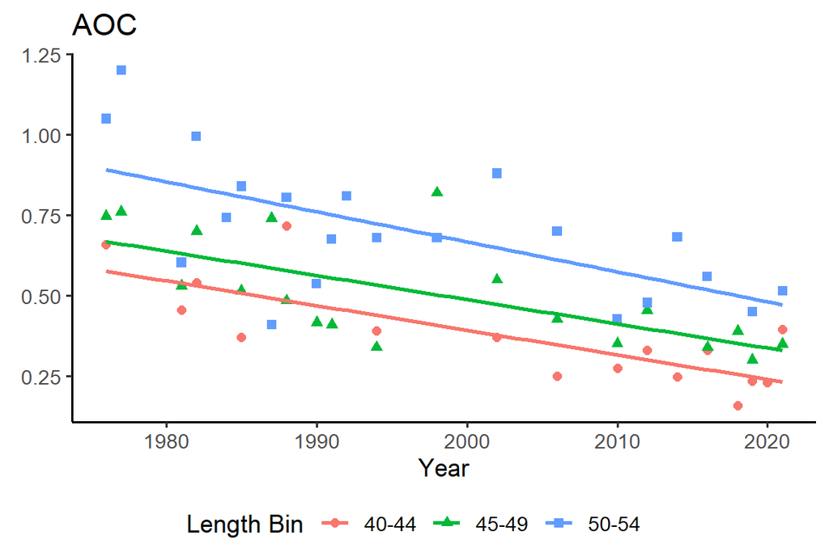

Figure 1.4: Temporal Mercury concentration (µg/g) trends for Walleye, grouped by region and top 3 sampled size bins. The most frequently sampled size bins were 45-49, 40-44 and 50-54 cm. Lines represent linear model fits. Results shown for: AOC.

A linear model detected a significant interaction between year and fish length (p = < 0.001). Trends were therefore assessed separately for the top 3 most sampled length bins: 45-49, 40-44 and 50-54 cm. Overall model R² = 0.66.In the AOC, 2 bins were declining, and 1 bin was stable. These trends were assessed using annual linear models by length bin.

**Tier 3C Overall Decision:** Supportive

## 1.5 Tier 3D: Half-life

A half-life for Mercury concentrations in Walleye was predicted for the AOC and reference sites using a generalized additive mixed model (GAMM). The log values of Mercury concentration were estimated using year as a linear predictor by region, with smooth effects controlling for fish length. Sampling sites were used as random effects to account for repeated sampling. The slope (on log scale) represents the annual rate of change in Mercury concentration, defined as k = -slope.

Table 1.3: Tier 3D (AOC): Time to reach an unrestrictive advisory of 8 meals/month for median-length fish

| Median Length (cm) | Predicted Conc | Target Conc | Years to Threshold | 95% CI | Outcome |
| --- | --- | --- | --- | --- | --- |
| 50 | 0.38 | 0.16 | 57.0 | 32.4–81.7 | Unsupportive |

A model test was performed to estimate the time required to reach a nonrestrictive monthly meal allowance for the median fish length (rounded to the nearest 5 cm) for sensitive populations. A timeline of 10 years or fewer is considered supportive of delisting, whereas a timeline of 10 or more years is unsupportive.

# 2 Final summary

Table 2.1: Summary of Tier 3 Evidence Lines and Outcomes

| Tier | Description | Metric | Outcome |
| --- | --- | --- | --- |
| Tier 3A | Virtual Advisory | General: 3/13 size bins restrictive or more restrictive than reference; Sensitive: 6/13 size bins restrictive or more restrictive than reference | Unsupportive |
| Tier 3B | Contaminant Concentration vs Reference | Significantly different smooth terms (p = 0.0492531); 11/11 lengths with higher AOC concentration | Unsupportive |
| Tier 3C | Temporal Trends | Significant length × year interaction (p = < 0.001); 2 declining, 1 stable, 0 increasing bins | Supportive |
| Tier 3D | Half-life / Time to Unrestrictive Advisory (AOC) | Approximately 57 years (95% CI 32.4–81.7) to reach an unrestrictive meal allowance for median-length (50 cm) fish. | Unsupportive |